# Sampling Poverty from California Census Tracts

**Author: Jacob Anderson**

**Sampling from American Community Survey Data**

In statistical computing we often work with stochastic methods. Stochastic methods do not have deterministic outputs. In other words, when you run a stochastic function with the same inputs different times, you will get different results.

```r
library(tidycensus)
library(sf)
library(dplyr)
library(ggplot2)
```

```r
### Save the census api key in script

tidycensus::census_api_key(
  key = "1d9fe19026f3759c68bc48e2c7ddf1b2b17ec47b",
  install = F,
  overwrite = F)
```

```r
### Setting the variables to extract from ACS

vars = c(total_pop = "B01001_001E",
         tot_pov = "B17020_002E")
ca_acs <- get_acs(geography = "tract",
                  state = "CA",
                  variables = vars,
                  year = 2022,
                  geometry = T,
                  output = "wide",
                  survey = "acs5"
) %>%
  st_transform(3310) %>%
  mutate(pct_pov = tot_pov / total_pop)
### Store the ACS data as data frame

tract_acs_df <- as.data.frame(ca_acs)

### Inspect the ACS table

head(tract_acs_df)
```

|  | GEOID | NAME | total_pop | B01001_001M | tot_pov | B17020_002M | geometry | pct_pov |
| --- | --- | --- | --- | --- | --- | --- | --- | --- |
| 1 | 06077005127 | Census Tract 51.27; San Joaquin County; California | 7580 | 1068 | 644 | 326 |  | 0.08496042 |
| 2 | 06077003406 | Census Tract 34.06; San Joaquin County; California | 3768 | 698 | 962 | 441 |  | 0.25530786 |
| 3 | 06077004402 | Census Tract 44.02; San Joaquin County; California | 5903 | 937 | 641 | 371 |  | 0.10858885 |
| 4 | 06077001700 | Census Tract 17; San Joaquin County; California | 4245 | 843 | 1092 | 543 |  | 0.25724382 |
| 5 | 06077000401 | Census Tract 4.01; San Joaquin County; California | 2856 | 338 | 588 | 245 |  | 0.20588235 |
| 6 | 06077003404 | Census Tract 34.04; San Joaquin County; California | 7182 | 1024 | 1823 | 800 |  | 0.25382902 |

```r
### Set seed for reproducability

set.seed(1)
```

**Task 1**: Simulate 100 samples from a normal distribution using the `rnorm` function. Mean and standard deviation are defined with `mean_val` and `std_val` variables below (you do not need to change these). Set the number of samples `n` and simulate 100 variables. Print your results.

```r
### Poverty rate
y <- tract_acs_df$pct_pov

y <- y[is.finite(y)]

n <- length(y)

### Population mean from ACS data

pop_mean <- mean(y, na.rm = T)

### Population standard deviation from ACS data

pop_sd <- sd(y, na.rm = T)

mean_val <- pop_mean

std_val <- pop_sd

### Define n as the number of samples

n <- 100

### Creating a new variable 'x' and populating the rnorm function with the mean and standard deviation values to simulate a random normal distribution

x <- rnorm(n, mean = mean_val, sd = std_val)

print(x)
```

```
  [1]  0.064474980  0.139087360  0.045209352  0.269103413  0.152521914  0.046605655  0.167066939  0.190175182  0.175204451
 [10]  0.094046070  0.261412846  0.158078992  0.064955134 -0.081807256  0.225782776  0.118034738  0.120682086  0.209103409
 [19]  0.197810198  0.176873354  0.206813835  0.194210362  0.129040917 -0.061052010  0.179261072  0.117003633  0.107824024
 [28] -0.013287455  0.078134202  0.160666932  0.247311727  0.112706200  0.157878978  0.117217652 -0.004658064  0.083951012
 [37]  0.085857969  0.116710316  0.223488900  0.192464038  0.107020141  0.098837886  0.186365679  0.173443611  0.058736789
 [46]  0.057010829  0.155752352  0.192957450  0.111825835  0.203325927  0.158840006  0.065803789  0.153591407  0.018155524
 [55]  0.254159047  0.304574039  0.088351057  0.026005322  0.174646148  0.109734323  0.343369470  0.118559136  0.185700326
 [64]  0.124752341  0.053715562  0.139561596 -0.044068855  0.257155264  0.136288351  0.322277321  0.165969115  0.056785059
 [73]  0.178422990  0.036140060  0.006709855  0.149016332  0.081344745  0.122275064  0.129020318  0.067876608  0.069797159
 [82]  0.109722902  0.230678610 -0.018151822  0.176877487  0.152838988  0.220087947  0.094157005  0.156253102  0.146773859
 [91]  0.072205533  0.233421512  0.229049826  0.186665039  0.268325387  0.173611536  0.004595280  0.069373791  0.009382757
[100]  0.078571637
```

**How Many Samples are Enough?**

Knowing how many samples are needed is an open question in stochastic computation, i.e. there is no definitive answer for it. In this section, you will seek an answer to a simplified version of this problem, how many samples do you need to estimate population statistics accurately?

```r
# Search between how closely you can estimate the population statistics for sample sizes between 2 and 10000

# Initialize a variable sample_mean_list as an empty list
# sample_mean_list <- ...

# Initialize a variable sample_std_list as an empty list
# sample_std_list <- ...

# Define a for loop where the sample size takes values 2 and 10000, with a step size (increment) of 1).

## Inside the Loop: Get Samples for the desired population mean and standard deviation
## Inside the Loop: Compute the Sample Mean and Sample Standard Deviation in two temporary variables mean_temp, std_temp (Hint: Sample std is different than population std)

## Inside the Loop: Append mean_temp and std_temp to sample_mean_list and sample_std_list, respectively
sample_mean_list <- c()
sample_std_list <- c()
# Create a for loop that iterates from 2 to 10,000 values by increments of 1
for(n in seq(2,10000,1)){
  # TODO Get a Sample for a Given N and Population Parameters
  # Using the same mean and standard deviation values and calling the rnorm function to simulate a random normal distribution
  x <- rnorm(n, mean_val, std_val)
  # TODO Compute Mean and Standard Deviation for the Sample
  # Pass in the 'x' value from the random simulation to create a new mean and standard deviation value
  mean_temp <- mean(x)
  std_temp <- sd(x)
  # TODO Append Sample and Standard Deviation Value to the List
  sample_mean_list <- append(sample_mean_list, mean_temp)
  sample_std_list <- append(sample_std_list, std_temp)
}

# Define a vector sample_vals that is a list that contains values between 2 and 10000 (Hint: checkout the seq function)
sample_vals <- seq(2,10000)

# TODO Plot sample mean values (y-axis) against sample size (x-axis) with a line plot. Make sure your plot has human-readable (Words not variable names) axes labels and title. Overlay dashed red lines that show the +- 1% band for the population mean

# plot()
# Creating the threshold band (+-1%) for the population mean with arithmetic operators
lower_range_mean <- mean_val * 0.99
upper_range_mean <- mean_val * 1.01
# Arguments for the plot function
# This is a line plot containing labels and two dashed lines for the threshold bands around the population mean
plot(sample_vals,
     sample_mean_list,
     type = "l",
     main = "Mean Plot",
     xlab = "Sample Size",
     ylab = "Sample Mean Values")

# Using the abline function for plotting
# Line type set to 2 to create dashed line representing the upper and lower threshold bands
abline(h = lower_range_mean, col = "deeppink", lty = 2)
```

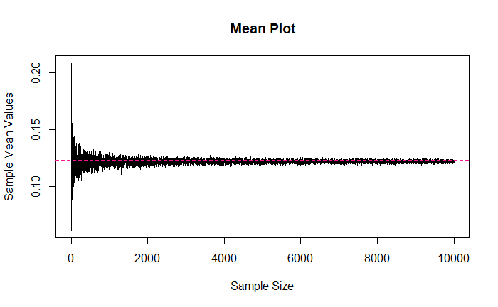

```r
abline(h = upper_range_mean, col = "deeppink", lty = 2)
```

```r
# TODO Plot another line plot following the same conventions for the sample standard deviation. Make sure to overlay dashed red lines that show the +- 1% band for the population mean

#plot()
#Creating the threshold band (+-1%) for the population standard deviation with arithmetic operators
lower_range_std <- std_val * 0.99
upper_range_std <- std_val * 1.01
# Arguments for the plot function
# This is a line plot containing labels and two dashed lines for the threshold bands around the population standard deviation
plot(sample_vals,
     sample_std_list,
     type = "l",
     main = "Standard Deviation Plot",
     xlab = "Sample Size",
     ylab = "Sample Standard Deviation Values")

# Using the abline function for plotting
# Line type set to 2 to create dashed line representing the upper and lower threshold bands
abline(h = lower_range_std, col = "deeppink", lty = 2)
```

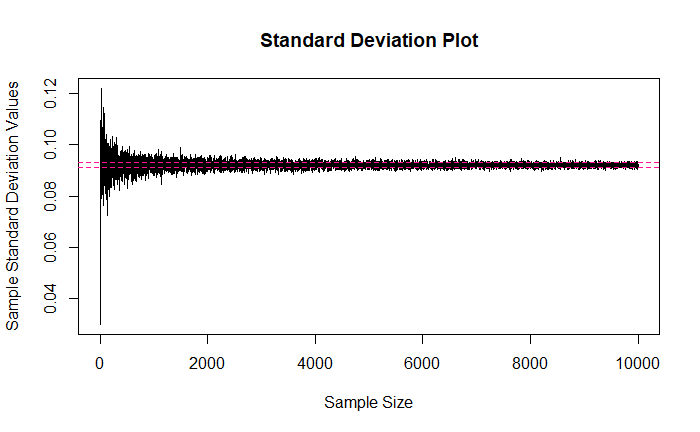

```r
abline(h = upper_range_std, col = "deeppink", lty = 2)
```

After inspecting the behavior of sample statistics for differing sample sizes, you will write your first R function that returns the smallest sample size at which both the sample mean and sample standard deviation is within 1% of the population mean and standard deviation, respectively.

Your function, get_rep_size will take 3 inputs: sample size list, sample mean list, and sample standard deviation list. Your function will return the sample size (integer) if it finds a sample size mean and standard deviation of which is within 1% of the population mean. If not, it will return a null value (`NULL`)

```r
# Define function get_rep_size with input variables sample_sizes, sample_means, sample_sds, pop_mean, pop_sd
# Hint 1: check out the which and intersect functions
# Hint 2: If none of the sample means and sds are close enough to that of the population, your function needs to return NULL (look into if-else structures in R)
# Setting up function 'get_rep_size' that will compute the minimum sample size from the population where the sample values fall within the threshold (+-1%)

get_rep_size <- function(sample_sizes, sample_means, sample_sds, pop_mean, pop_sd){
  lower_mean <- pop_mean * 0.99
  upper_mean <- pop_mean * 1.01
  lower_sd <- pop_sd * 0.99
  upper_sd <- pop_sd * 1.01
  mean_ind <- which(sample_means >= lower_mean & sample_means <= upper_mean)
  sd_ind <- which(sample_sds >= lower_sd & sample_sds <= upper_sd)
  index <- intersect(mean_ind, sd_ind)

  if (length(index) > 0){
    return(sample_sizes[min(index)])
  }else {
    return(NULL)
  }
}
```

```r
## Run function from the previous step to define the smallest representative sample size
pop_mean <- mean(y, na.rm = T)
pop_sd <- sd(y, na.rm = T)
sample_size <- get_rep_size(sample_vals, sample_mean_list,
                            sample_std_list, pop_mean, pop_sd)


## Obtain samples for the sample size you found with your function, 100 times and for every run record the sample mean and standard deviation
# Create two empty lists that will take the sample mean and standard deviation values
sample_mean <- c()
sample_sd <- c()

for(i in seq(100)){
  # TODO Sample for the chosen number of samples
  x <- rnorm(sample_size, mean = pop_mean, sd = pop_sd)
  # TODO Append Mean and Standard deviation to list
  # Creating the sample mean and standard deviation variables to store the sampled values as a variable
  sample_mean <- append(sample_mean, mean(x))
  sample_sd <- append(sample_sd, sd(x))
}
```

```r
### Create a Data Frame with columns Sample Size, Sample Mean, Sample SD and populate it with corresponding lists from the previous steps

plot_df <- data.frame()

print(paste0("Data Frame Column Names Before Assignment: ", colnames(plot_df)))
```

```
[1] "Data Frame Column Names Before Assignment: "
```

```r
### Assigning three new variables into the Data Frame

plot_df <- data.frame('Sample Size' = sample_size,
                      'Sample_Mean' = sample_mean,
                      'Sample_SD' = sample_sd)

### Display the Data Frame

head(plot_df)
```

|  | Sample.Size | Sample_Mean | Sample_SD |
| --- | --- | --- | --- |
| 1 | 112 | 0.1191393 | 0.08893786 |
| 2 | 112 | 0.1202582 | 0.08831137 |
| 3 | 112 | 0.1363100 | 0.09695139 |
| 4 | 112 | 0.1287674 | 0.08903861 |
| 5 | 112 | 0.1375372 | 0.10215398 |
| 6 | 112 | 0.1280582 | 0.10219720 |

```r
### Plot the probability distribution function for sample means
### Using ggplot to plot the PDF of the sample mean values
### Using additive operators to add the different plot components: histogram of the sample mean, dashed mean line, pdf curve, and labels

ggplot(plot_df, aes(x = Sample_Mean)) +
  geom_density(alpha = 0.3, fill = "deeppink") +
  geom_vline(aes(xintercept = mean(sample_mean)),
             color = "red",
             linetype = "dashed",
             size = 1) +
  labs(title = "Probability Distribution Function Plot for the Sample Mean Values ",
       x = "Sample Mean",
       y = "Density") +
  theme_minimal()
```

[output not shown]